# mod_2_mcspadden_diana

Diana McSpadden

2/12/2021

# Module 2 Homework

## H. Diana McSpadden (hdm5s)

You will complete exercises 9, 14, and 15 at the end of Chapter 3 of your textbook.

```r
library(ggplot2)
library(tidyverse)
library(plotly)
library(scales)
library("GGally")
library(ISLR)
library(gridExtra)
library(broom)
```

# 9. This question involves the use of multiple linear regression on the Auto data set.

```r
head(Auto)
```

```
#>   mpg cylinders displacement horsepower weight acceleration year origin
#> 1  18         8          307        130   3504         12.0   70      1
#> 2  15         8          350        165   3693         11.5   70      1
#> 3  18         8          318        150   3436         11.0   70      1
#> 4  16         8          304        150   3433         12.0   70      1
#> 5  17         8          302        140   3449         10.5   70      1
#> 6  15         8          429        198   4341         10.0   70      1
#>                        name
#> 1 chevrolet chevelle malibu
#> 2         buick skylark 320
#> 3        plymouth satellite
#> 4             amc rebel sst
#> 5               ford torino
#> 6          ford galaxie 500
```

```r
#view(Auto)
```

## (a) Produce a scatterplot matrix which includes all of the variables in the data set.

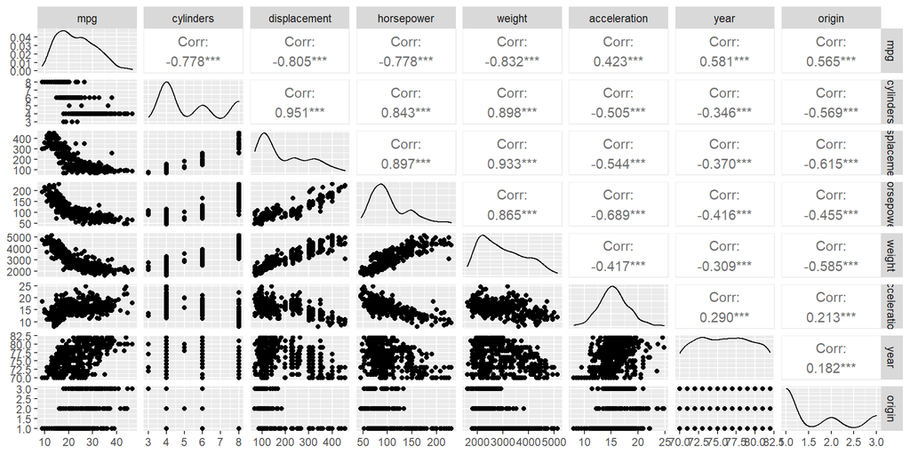

```r
ggpairs(Auto[-9], lower = list(continuous = "points", combo = "dot_no_facet"), progress = F)
```

## (b) Compute the matrix of correlations between the variables …

using the function cor(). You will need to exclude the name variable, cor() which is qualitative.

```r
cor(Auto[,-9])
```

```
#>                     mpg  cylinders displacement horsepower     weight
#> mpg           1.0000000 -0.7776175   -0.8051269 -0.7784268 -0.8322442
#> cylinders    -0.7776175  1.0000000    0.9508233  0.8429834  0.8975273
#> displacement -0.8051269  0.9508233    1.0000000  0.8972570  0.9329944
#> horsepower   -0.7784268  0.8429834    0.8972570  1.0000000  0.8645377
#> weight       -0.8322442  0.8975273    0.9329944  0.8645377  1.0000000
#> acceleration  0.4233285 -0.5046834   -0.5438005 -0.6891955 -0.4168392
#> year          0.5805410 -0.3456474   -0.3698552 -0.4163615 -0.3091199
#> origin        0.5652088 -0.5689316   -0.6145351 -0.4551715 -0.5850054
#>              acceleration       year     origin
#> mpg             0.4233285  0.5805410  0.5652088
#> cylinders      -0.5046834 -0.3456474 -0.5689316
#> displacement   -0.5438005 -0.3698552 -0.6145351
#> horsepower     -0.6891955 -0.4163615 -0.4551715
#> weight         -0.4168392 -0.3091199 -0.5850054
#> acceleration    1.0000000  0.2903161  0.2127458
#> year            0.2903161  1.0000000  0.1815277
#> origin          0.2127458  0.1815277  1.0000000
```

## (c) Use the lm() function to perform a multiple linear regression …

with mpg as the response and all other variables except name as the predictors. Use the summary() function to print the results. Comment on the output.

```r
lm.model.all  = lm(mpg~.-name, data=Auto)
summary(lm.model.all)
```

```
#>
#> Call:
#> lm(formula = mpg ~ . - name, data = Auto)
#>
#> Residuals:
#>     Min      1Q  Median      3Q     Max
#> -9.5903 -2.1565 -0.1169  1.8690 13.0604
#>
#> Coefficients:
#>                Estimate Std. Error t value Pr(>|t|)
#> (Intercept)  -17.218435   4.644294  -3.707  0.00024 ***
#> cylinders     -0.493376   0.323282  -1.526  0.12780
#> displacement   0.019896   0.007515   2.647  0.00844 **
#> horsepower    -0.016951   0.013787  -1.230  0.21963
#> weight        -0.006474   0.000652  -9.929  < 2e-16 ***
#> acceleration   0.080576   0.098845   0.815  0.41548
#> year           0.750773   0.050973  14.729  < 2e-16 ***
#> origin         1.426141   0.278136   5.127 4.67e-07 ***
#> ---
#> Signif. codes:  0 '***' 0.001 '**' 0.01 '*' 0.05 '.' 0.1 ' ' 1
#>
#> Residual standard error: 3.328 on 384 degrees of freedom
#> Multiple R-squared:  0.8215, Adjusted R-squared:  0.8182
#> F-statistic: 252.4 on 7 and 384 DF,  p-value: < 2.2e-16
```

### Comments

**Is there a relationship between the predictors and the response?**

Yes, there is a relationship between the predictors and response. The model is significant with an F-statistic of 252.4, and significant p-value. The model’s R2 is 0.8215 indicating that ~82% of the variability in mpg can be explained by the model.

**Which predictors appear to have a statistically significant relationship to the response?**

In an additive model of mpg vs cylinders+displacement+horsepower+weight+acceleration+year+origin I notice the following from the model summary: 1. cylinders, horsepower, and acceleration are not statistically significant 2. displacement, weight, year, and origin are statistically significant.

**What does the coefficient for the year variable suggest?**

The coefficient for year suggests that when the other predictors are held constant, for cars represented in the sample, a car that is one year newer than another car produces an increase of .75 in the miles per gallon fuel use of a car.

## (d) Use the plot() function to produce diagnostic plots …

of the linear regression fit.

**Useful Plotting Functions** Here are useful plotting functions referenced from Module 2 lab.

I have commented the code to document parts I researched.

```r
# From Module 2 Lab, the Residual Plot
scatterall <- function(lm.fit){
  lm.fit %>%
  ggplot(aes(.fitted, .resid)) + geom_point() +
    stat_smooth(method="loess") +
    geom_hline(yintercept=0, col="red", linetype="dashed") +
    labs(x="Fitted values", y="Residuals", title="Residual vs Fitted Plot") +
    theme_bw()
}


# From Module 2 lab and Tidyverse website, the qq plot # https://ggplot2.tidyverse.org/reference/geom_qq.html
q_q <- function(lm.model.fit){
  lm.model.fit %>% augment() %>% # augment adds the standardized residuals that we need
  ggplot(aes(sample=.std.resid)) +
  stat_qq() + stat_qq_line() +
  labs(x="Theoretical Quantiles", y="Sample Quantiles", title="Q-Q Plot") +
  theme_bw()
}

# From Module 2 lab the residual vs. leverage
# https://rpubs.com/therimalaya/43190
resVlev <- function(lm.model.fit){
  lm.model.fit %>% augment() %>% rownames_to_column() %>% # augment gives us residuals and hat values
  ggplot(aes(.hat,.std.resid, label=rowname)) + # hat values and residuals
    geom_point(aes(size=.cooksd), na.rm=TRUE) +
    stat_smooth(method="loess", na.rm=TRUE) +
    scale_x_continuous(name="Leverage") +
    scale_y_continuous(name="Standardized Residuals") +
    ggtitle("Residual vs Leverage Plot") +
    theme_bw() + theme(legend.position="bottom")
}

# Cooks Distance For Influential Data Points
#A general rule of thumb is that any point with a Cook’s Distance over 4/n (where n is the total number of data points) is considered to be an outlier.
cookVals <- function(lm.fit) {
  lm.fit %>% augment() %>%
  ggplot(aes(seq_along(.cooksd), .cooksd))+
  geom_bar(stat="identity", position="identity") +
  labs(x="Obs. Number", y=TeX("Cook's distance"),
       title="Cook's Distance - Influential Data Points") + theme_bw()
}

# plot the hat values by their sequence in the observations ??????
hatVals <- lm.model.all %>% augment() %>%
  ggplot(aes(seq_along(.hat), .hat))+
  geom_bar(stat="identity", position="identity") +
  labs(x="Obs. Number", y=TeX("Hat values"),
       title="Hat values") + theme_bw()
```

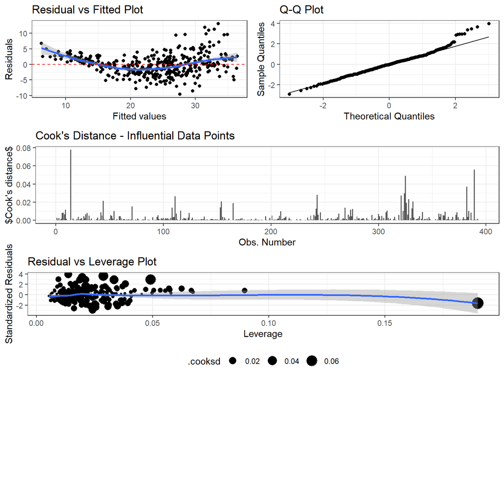

```r
grid.arrange(scatterall(lm.model.all), q_q(lm.model.all), cookVals(lm.model.all), resVlev(lm.model.all),
             widths=c(1,1),
             layout_matrix = rbind(c(1, 2),
                                   c(3, 3),
                                   c(4, 4),
                                   c(5,5)))
```

```r
print(paste("High Leverage Value:", 2/sqrt(nrow(Auto))))
```

```
#> [1] "High Leverage Value: 0.101015254455221"
```

```r
which.max(hatvalues(lm.model.all))
```

```
#> 14
#> 14
```

### Comments

**Do the residual plots suggest any unusually large outliers?**

**Does the leverage plot identify any observations with unusually high leverage?**

From the Residual vs. Leverage plot there is clearly one value that is **high leverage**, i.e. past the 0.1 value (2/sqrt(n)). (Reference: ‘Introduction to Linear Regression Analysis’). The observation of note is #14.

## (e) Use the * and : symbols …

to fit linear regression models with interaction effects. Do any interactions appear to be statistically significant?

### Comments

Weight and cylinders make the most sense to me as possibly have an interaction effect. As cylinders are added to the engine, I would imagine that additional weight would have an greater impact on mpg. I tried a model with an interaction effect between cylinders and weight.

I ran this model a few times, trying to tweak it for better results. The first time I ran with all predictors + an interaction between weight and cylinders. The interaction was statistically significant (p-value < 2e-16); however, the acceleration predictor was insignificant. The Adjusted R2 value was .85 (an increase from the full model without interaction with an Adjusted R2 of .82).

I then removed acceleration from the model; as expected, the R2 did not improve.

I then added another interaction of year * cylinders, due to thinking that with newer technology the number of cylinders may have a different effect on mpg. This increased the Adjusted R2 to .86. Displacement was no longer significant in this model.

```r
#lm.model.int.w.c = lm(mpg~.-name+(weight*cylinders), data=Auto)

#lm.model.int.w.c = lm(mpg~.-name-acceleration+(weight*cylinders), data=Auto)

lm.model.int.w.c = lm(mpg~.-name-acceleration+(weight*cylinders)+(year*cylinders), data=Auto)
summary(lm.model.int.w.c)
```

```
#>
#> Call:
#> lm(formula = mpg ~ . - name - acceleration + (weight * cylinders) +
#>     (year * cylinders), data = Auto)
#>
#> Residuals:
#>     Min      1Q  Median      3Q     Max
#> -9.7409 -1.6013 -0.1702  1.3054 12.1436
#>
#> Coefficients:
#>                    Estimate Std. Error t value Pr(>|t|)
#> (Intercept)      -5.181e+01  1.216e+01  -4.260 2.58e-05 ***
#> cylinders         7.305e+00  2.348e+00   3.111  0.00200 **
#> displacement      8.673e-03  6.670e-03   1.300  0.19429
#> horsepower       -4.960e-02  9.819e-03  -5.052 6.78e-07 ***
#> weight           -1.358e-02  1.052e-03 -12.901  < 2e-16 ***
#> year              1.544e+00  1.485e-01  10.396  < 2e-16 ***
#> origin            8.294e-01  2.527e-01   3.282  0.00112 **
#> cylinders:weight  1.354e-03  1.622e-04   8.349 1.27e-15 ***
#> cylinders:year   -1.528e-01  2.824e-02  -5.412 1.10e-07 ***
#> ---
#> Signif. codes:  0 '***' 0.001 '**' 0.01 '*' 0.05 '.' 0.1 ' ' 1
#>
#> Residual standard error: 2.918 on 383 degrees of freedom
#> Multiple R-squared:  0.8631, Adjusted R-squared:  0.8603
#> F-statistic: 301.9 on 8 and 383 DF,  p-value: < 2.2e-16
```

## (f) Try a few different transformations of the variables, such as log(X), and sqrt(X), and X^2

Comment on your findings.

**Process**

From the correlation scatter plots it appears there is a non-linear relationship between: * mpg and weight * mpg and displacement * and mpg and horsepower.

I removed displacement and acceleration from the full model because they were no longer significant after the additive terms were included.

To correct for the non-linear residuals, I will attempt some transformations on the predictor variables. From the residual plot it appears a quadratic relationship exists. Individually, I added square terms for both weight and horsepower.

This results in a R Adjusted of .87 and even more importantly, the non-linear residual plot issue has been corrected. However, with the quadratic terms for weight and horsepower, I now have **3 high leverage points**.

```r
#lm.model.int.trans = lm(mpg~.-name-acceleration+(weight*cylinders)+(year*cylinders), data=Auto)

#lm.model.int.trans = lm(mpg~.-name-acceleration-displacement+(year*cylinders)+I(weight^2), data=Auto)

lm.model.int.trans = lm(mpg~.-name-acceleration-displacement+(year*cylinders)+I(weight^2)+I(horsepower^2), data=Auto)

summary(lm.model.int.trans)
```

```
#>
#> Call:
#> lm(formula = mpg ~ . - name - acceleration - displacement + (year *
#>     cylinders) + I(weight^2) + I(horsepower^2), data = Auto)
#>
#> Residuals:
#>     Min      1Q  Median      3Q     Max
#> -7.8636 -1.6166 -0.0594  1.3286 11.7423
#>
#> Coefficients:
#>                   Estimate Std. Error t value Pr(>|t|)
#> (Intercept)     -4.686e+01  1.184e+01  -3.957 9.05e-05 ***
#> cylinders        9.690e+00  2.167e+00   4.473 1.02e-05 ***
#> horsepower      -1.423e-01  2.974e-02  -4.786 2.43e-06 ***
#> weight          -1.480e-02  1.806e-03  -8.198 3.71e-15 ***
#> year             1.408e+00  1.487e-01   9.469  < 2e-16 ***
#> origin           7.619e-01  2.354e-01   3.237 0.001313 **
#> I(weight^2)      1.522e-06  2.640e-07   5.766 1.67e-08 ***
#> I(horsepower^2)  3.967e-04  1.059e-04   3.747 0.000206 ***
#> cylinders:year  -1.244e-01  2.823e-02  -4.408 1.36e-05 ***
#> ---
#> Signif. codes:  0 '***' 0.001 '**' 0.01 '*' 0.05 '.' 0.1 ' ' 1
#>
#> Residual standard error: 2.848 on 383 degrees of freedom
#> Multiple R-squared:  0.8695, Adjusted R-squared:  0.8668
#> F-statistic: 319.1 on 8 and 383 DF,  p-value: < 2.2e-16
```

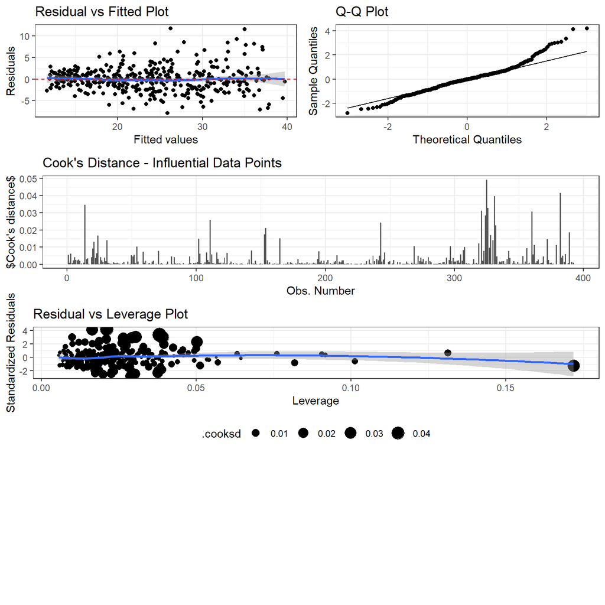

```r
grid.arrange(scatterall(lm.model.int.trans), q_q(lm.model.int.trans), cookVals(lm.model.int.trans), resVlev(lm.model.int.trans),
             widths=c(1,1),
             layout_matrix = rbind(c(1, 2),
                                   c(3, 3),
                                   c(4, 4),
                                   c(5,5)))
```

# 14 This problem focuses on the collinearity problem.

## (a) Perform the following commands in R:

set .seed (1)  
x1=runif (100)  
x2 =0.5* x1+rnorm (100) /10  
y=2+2* x1 +0.3* x2+rnorm (100)

The last line corresponds to creating a linear model in which y is a function of x1 and x2. Write out the form of the linear model. What are the regression coefficients?

```r
set.seed (1)
x1=runif(100) #Generates random compositions with a uniform distribution on the (rcomp) simplex.
x2 =0.5* x1+rnorm(100) /10
y=2+2* x1 +0.3* x2+rnorm(100)
```

## (b) What is the correlation between x1 and x2?

Create a scatter plot displaying the relationship between the variables.

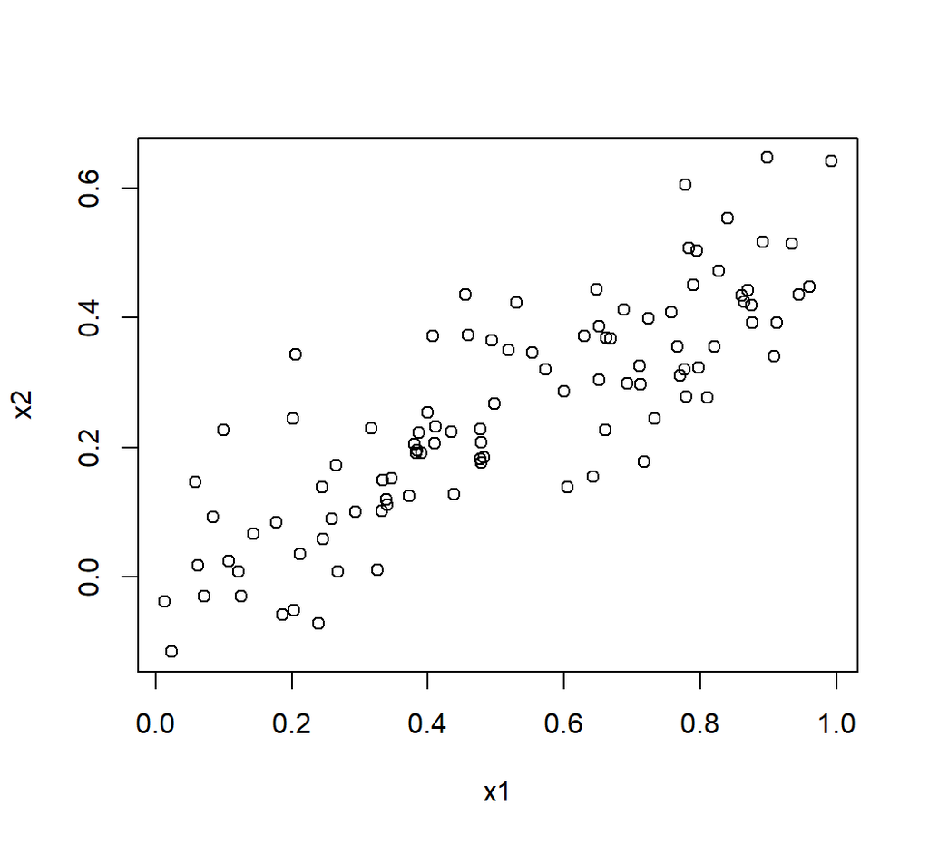

```r
plot(x1,x2)
```

**Answer q14b:** There appears to be a positive linear relationship between x1 and x2.

## (c) Using this data, fit a least squares regression …

to predict y using x1 and x2.

```r
lm.x1.x2 = lm(y~x1+x2)
summary(lm.x1.x2)
```

```
#>
#> Call:
#> lm(formula = y ~ x1 + x2)
#>
#> Residuals:
#>     Min      1Q  Median      3Q     Max
#> -2.8311 -0.7273 -0.0537  0.6338  2.3359
#>
#> Coefficients:
#>             Estimate Std. Error t value Pr(>|t|)
#> (Intercept)   2.1305     0.2319   9.188 7.61e-15 ***
#> x1            1.4396     0.7212   1.996   0.0487 *
#> x2            1.0097     1.1337   0.891   0.3754
#> ---
#> Signif. codes:  0 '***' 0.001 '**' 0.01 '*' 0.05 '.' 0.1 ' ' 1
#>
#> Residual standard error: 1.056 on 97 degrees of freedom
#> Multiple R-squared:  0.2088, Adjusted R-squared:  0.1925
#> F-statistic:  12.8 on 2 and 97 DF,  p-value: 1.164e-05
```

```r
confint(lm.x1.x2)
```

```
#>                    2.5 %   97.5 %
#> (Intercept)  1.670278673 2.590721
#> x1           0.008213776 2.870897
#> x2          -1.240451256 3.259800
```

### Describe the results obtained. What are ˆβ0, ˆβ1, and ˆβ2? How do these relate to the true β0, β1, and β2?

**Answer q14c part 1**: x1 is significant, but x2 is not. The complete model is significant (F-statistic of 12.8 and significant p-value).

- ˆβ0: 2.13
- ˆβ1: 1.44
- ˆβ2: 1.01

The estimated coefficients represent the values that produce the least square residuals fitting y with x1 and x2 in the model
$$y = \hat{B0} + \hat{B1}x1 + \hat{B2}x2$$

### Can you reject the null hypothesis H0 : β1 = 0?

**Answer q14c part 2*: Yes, we can reject the null hypothesis. The p-value for the predictor is significant, and the 95% CI does not contain 0.

### How about the null hypothesis H0 : β2 = 0?

**Answer q14c part 3**: No, we cannot reject the hull hypothesis for β2. First x2’s p-value is insignificant in the model, and the 95% CI for β2 includes 0.

## (d) Now fit a least squares regression to predict y using only x1.

Comment on your results. Can you reject the null hypothesis H0 : β1 = 0?

```r
lm.x1 = lm(y~x1)
summary(lm.x1)
```

```
#>
#> Call:
#> lm(formula = y ~ x1)
#>
#> Residuals:
#>      Min       1Q   Median       3Q      Max
#> -2.89495 -0.66874 -0.07785  0.59221  2.45560
#>
#> Coefficients:
#>             Estimate Std. Error t value Pr(>|t|)
#> (Intercept)   2.1124     0.2307   9.155 8.27e-15 ***
#> x1            1.9759     0.3963   4.986 2.66e-06 ***
#> ---
#> Signif. codes:  0 '***' 0.001 '**' 0.01 '*' 0.05 '.' 0.1 ' ' 1
#>
#> Residual standard error: 1.055 on 98 degrees of freedom
#> Multiple R-squared:  0.2024, Adjusted R-squared:  0.1942
#> F-statistic: 24.86 on 1 and 98 DF,  p-value: 2.661e-06
```

```r
confint(lm.x1)
```

```
#>                2.5 %   97.5 %
#> (Intercept) 1.654488 2.570299
#> x1          1.189529 2.762329
```

**Answer q14d**: The SLR model ffor x1 is significant with a p-value of 2.661e-06, and the 95% CI for x1 does not include 0. We can reject the null hypothesis that β1 = 0.

## (e) Now fit a least squares regression to predict y using only x2.

Comment on your results. Can you reject the null hypothesis H0 : β1 = 0

```r
lm.x2 = lm(y~x2)
summary(lm.x2)
```

```
#>
#> Call:
#> lm(formula = y ~ x2)
#>
#> Residuals:
#>      Min       1Q   Median       3Q      Max
#> -2.62687 -0.75156 -0.03598  0.72383  2.44890
#>
#> Coefficients:
#>             Estimate Std. Error t value Pr(>|t|)
#> (Intercept)   2.3899     0.1949   12.26  < 2e-16 ***
#> x2            2.8996     0.6330    4.58 1.37e-05 ***
#> ---
#> Signif. codes:  0 '***' 0.001 '**' 0.01 '*' 0.05 '.' 0.1 ' ' 1
#>
#> Residual standard error: 1.072 on 98 degrees of freedom
#> Multiple R-squared:  0.1763, Adjusted R-squared:  0.1679
#> F-statistic: 20.98 on 1 and 98 DF,  p-value: 1.366e-05
```

```r
confint(lm.x2)
```

```
#>                2.5 %   97.5 %
#> (Intercept) 2.003116 2.776783
#> x2          1.643324 4.155846
```

**Answer q14e**: The SLR model for x2 is significant with a p-value of 1.37e-05, and the 95% CI for x2 does not include 0. We can reject the null hypothesis that β1 = 0.

## (f) Do the results obtained in (c)–(e) contradict each other?

Explain your answer.

**Answer q14f**: No, the results do not contridict each other. The significance results are only for the model including the predictors. x2 is only insignificant in a model that also includes x1.

## (g) Now suppose we obtain one additional observation, …

which was unfortunately mis-measured:

- x1=c(x1 , 0.1)
- x2=c(x2 , 0.8)
- y=c(y,6)

```r
x1=c(x1 , 0.1)
x2=c(x2 , 0.8)
y=c(y,6)
```

Re-fit the linear models from (c) to (e) using this new data. What effect does this new observation have on the each of the models? In each model, is this observation an outlier? A high-leverage point? Both? Explain your answers.

```r
lm.x1.x2 = lm(y~x1+x2)
summary(lm.x1.x2)
```

```
#>
#> Call:
#> lm(formula = y ~ x1 + x2)
#>
#> Residuals:
#>      Min       1Q   Median       3Q      Max
#> -2.73348 -0.69318 -0.05263  0.66385  2.30619
#>
#> Coefficients:
#>             Estimate Std. Error t value Pr(>|t|)
#> (Intercept)   2.2267     0.2314   9.624 7.91e-16 ***
#> x1            0.5394     0.5922   0.911  0.36458
#> x2            2.5146     0.8977   2.801  0.00614 **
#> ---
#> Signif. codes:  0 '***' 0.001 '**' 0.01 '*' 0.05 '.' 0.1 ' ' 1
#>
#> Residual standard error: 1.075 on 98 degrees of freedom
#> Multiple R-squared:  0.2188, Adjusted R-squared:  0.2029
#> F-statistic: 13.72 on 2 and 98 DF,  p-value: 5.564e-06
```

```r
confint(lm.x1.x2)
```

```
#>                  2.5 %   97.5 %
#> (Intercept)  1.7675696 2.685814
#> x1          -0.6357561 1.714635
#> x2           0.7331298 4.296009
```

```r
lm.x1 = lm(y~x1)
summary(lm.x1)
```

```
#>
#> Call:
#> lm(formula = y ~ x1)
#>
#> Residuals:
#>     Min      1Q  Median      3Q     Max
#> -2.8897 -0.6556 -0.0909  0.5682  3.5665
#>
#> Coefficients:
#>             Estimate Std. Error t value Pr(>|t|)
#> (Intercept)   2.2569     0.2390   9.445 1.78e-15 ***
#> x1            1.7657     0.4124   4.282 4.29e-05 ***
#> ---
#> Signif. codes:  0 '***' 0.001 '**' 0.01 '*' 0.05 '.' 0.1 ' ' 1
#>
#> Residual standard error: 1.111 on 99 degrees of freedom
#> Multiple R-squared:  0.1562, Adjusted R-squared:  0.1477
#> F-statistic: 18.33 on 1 and 99 DF,  p-value: 4.295e-05
```

```r
confint(lm.x1)
```

```
#>                 2.5 %   97.5 %
#> (Intercept) 1.7827720 2.731083
#> x1          0.9474479 2.583943
```

```r
lm.x2 = lm(y~x2)
summary(lm.x2)
```

```
#>
#> Call:
#> lm(formula = y ~ x2)
#>
#> Residuals:
#>      Min       1Q   Median       3Q      Max
#> -2.64729 -0.71021 -0.06899  0.72699  2.38074
#>
#> Coefficients:
#>             Estimate Std. Error t value Pr(>|t|)
#> (Intercept)   2.3451     0.1912  12.264  < 2e-16 ***
#> x2            3.1190     0.6040   5.164 1.25e-06 ***
#> ---
#> Signif. codes:  0 '***' 0.001 '**' 0.01 '*' 0.05 '.' 0.1 ' ' 1
#>
#> Residual standard error: 1.074 on 99 degrees of freedom
#> Multiple R-squared:  0.2122, Adjusted R-squared:  0.2042
#> F-statistic: 26.66 on 1 and 99 DF,  p-value: 1.253e-06
```

```r
confint(lm.x2)
```

```
#>                2.5 %   97.5 %
#> (Intercept) 1.965688 2.724526
#> x2          1.920513 4.317586
```

Box plots For x1, x2, and y.  
The new data point is: * x1: 0.1 * x2: 0.8 * y: 6

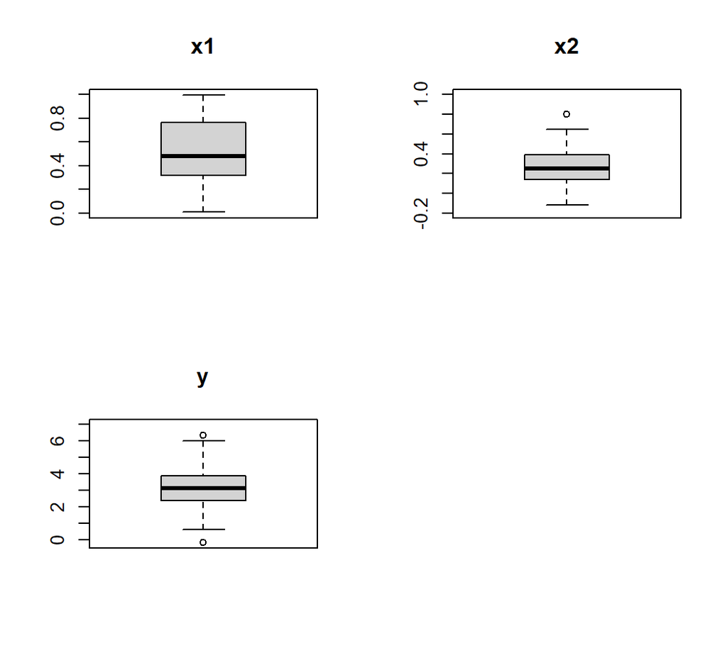

```r
#view(x2)
par(mfrow=c(2,2))

boxplot(x1, main='x1', ylim = c(0, 1))

boxplot(x2, main='x2', ylim = c(-0.2, 1))

boxplot(y, main='y', ylim = c(-0.2, 7))
```

```r
print(which.max(hatvalues(lm.x1.x2)))
```

```
#> 101
#> 101
```

```r
print(paste("Min x1: ",min(x1), " Max x1: ", max(x1), " Min x2: ", min(x2), " Max x2: ", max(x2), "Min y: ", min(y), "Max y: ", max(y)))
```

```
#> [1] "Min x1:  0.0133903331588954  Max x1:  0.991906094830483  Min x2:  -0.115993619678907  Max x2:  0.8 Min y:  -0.15291312324839 Max y:  6.33185993180406"
```

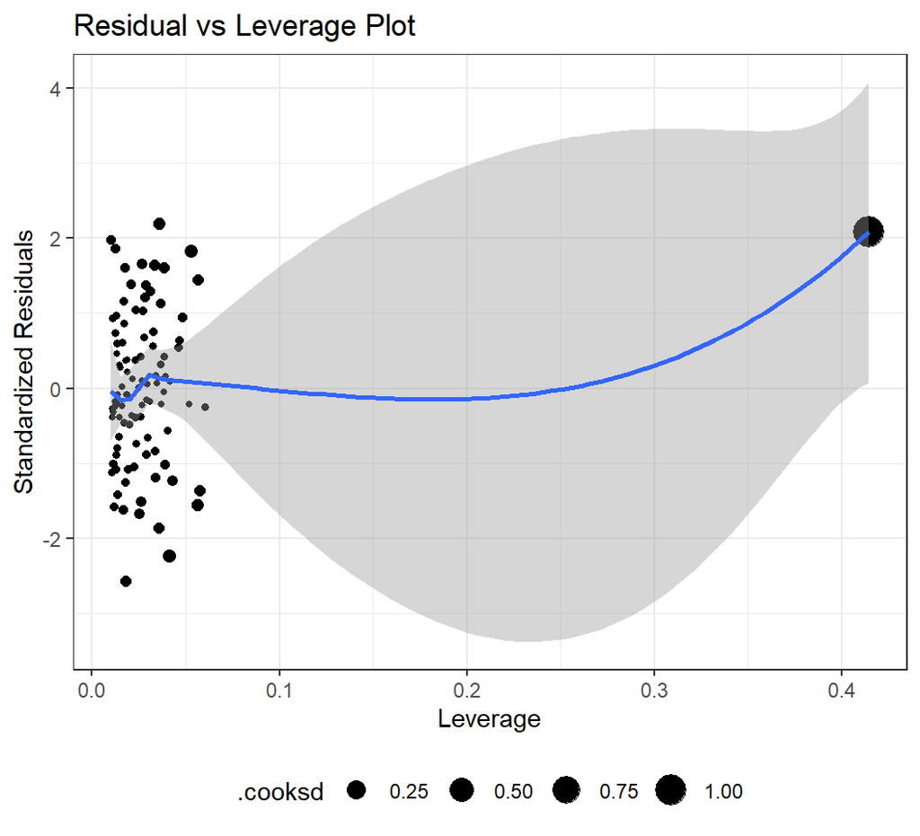

```r
resVlev(lm.x1.x2)
```

# 15 This problem involves the Boston data set, …

which we saw in the lab for this chapter. We will now try to predict per capita crime rate using the other variables in this data set. In other words, per capita crime rate is the response, and the other variables are the predictors.

## (a) For each predictor…

fit a simple linear regression model to predict the response. Describe your results. In which of the models is there a statistically significant association between the predictor and the response? Create some plots to back up your assertions.

```r
library(MASS)
dfBoston = Boston
head(dfBoston)
```

```
#>      crim zn indus chas   nox    rm  age    dis rad tax ptratio  black lstat
#> 1 0.00632 18  2.31    0 0.538 6.575 65.2 4.0900   1 296    15.3 396.90  4.98
#> 2 0.02731  0  7.07    0 0.469 6.421 78.9 4.9671   2 242    17.8 396.90  9.14
#> 3 0.02729  0  7.07    0 0.469 7.185 61.1 4.9671   2 242    17.8 392.83  4.03
#> 4 0.03237  0  2.18    0 0.458 6.998 45.8 6.0622   3 222    18.7 394.63  2.94
#> 5 0.06905  0  2.18    0 0.458 7.147 54.2 6.0622   3 222    18.7 396.90  5.33
#> 6 0.02985  0  2.18    0 0.458 6.430 58.7 6.0622   3 222    18.7 394.12  5.21
#>   medv
#> 1 24.0
#> 2 21.6
#> 3 34.7
#> 4 33.4
#> 5 36.2
#> 6 28.7
```

I set the chas predictor to a categorical/factor variable.

```r
dfBoston$chas <- factor(dfBoston$chas)
```

To create a DataFrame of all the coefs, standard error, and p-values I worked from an example here: https://www.r-bloggers.com/2017/02/how-to-create-a-loop-to-run-multiple-regression-models/

```r
# create vectors of the of outcomes
out_start = 2
out_end = 14
out_nvar = out_end - out_start+1
out_variable = rep(NA, out_nvar)
out_beta = rep(NA, out_nvar)
out_se = rep(NA, out_nvar)
out_pvalue = rep(NA, out_nvar)



for (i in out_start:out_end){
  predictor = colnames(dfBoston)[i]

  model = lm(crim ~ get(predictor), data=dfBoston)

  Vcov = vcov(model, useScale = FALSE)
  beta = coef(model)
  se = sqrt(diag(Vcov))
  zval = beta / se
  pval <- 2 * pnorm(abs(zval), lower.tail = FALSE)


  #print(pval)

  #print(paste("Vcov", i, ": ", Vcov))
  #print(paste("beta: ", beta))
  #print(paste("se: ", se))
  #print(paste("zval: ", zval))
  #print(paste("pval: ", pval))

  out_beta[i] = as.numeric(beta[2])
  out_se[i] = as.numeric(se[2])
  out_pvalue[i] = as.numeric(pval[2])
  out_variable[i] = predictor
  #number = number + 1

}

outcome = data.frame(out_variable, out_beta, out_se, out_pvalue)

outcome
```

```
#>    out_variable    out_beta      out_se   out_pvalue
#> 1          <NA>          NA          NA           NA
#> 2            zn -0.07393498 0.016094596 4.352956e-06
#> 3         indus  0.50977633 0.051024332 1.671462e-23
#> 4          chas -1.89277655 1.506115484 2.088524e-01
#> 5           nox 31.24853120 2.999190381 2.031009e-25
#> 6            rm -2.68405122 0.532041083 4.539497e-07
#> 7           age  0.10778623 0.012736436 2.609779e-17
#> 8           dis -1.55090168 0.168330031 3.157841e-20
#> 9           rad  0.61791093 0.034331820 2.012573e-72
#> 10          tax  0.02974225 0.001847415 2.576402e-58
#> 11      ptratio  1.15198279 0.169373609 1.035856e-11
#> 12        black -0.03627964 0.003873154 7.465832e-21
#> 13        lstat  0.54880478 0.047760971 1.469952e-30
#> 14         medv -0.36315992 0.038390175 3.087982e-21
```

From the SLR models, each variable is significant on its own **except** chas; which makes sense as chas is a binary categorical variable.

The correlation plots will demonstrate these relationships when looking at the crim row (or column)

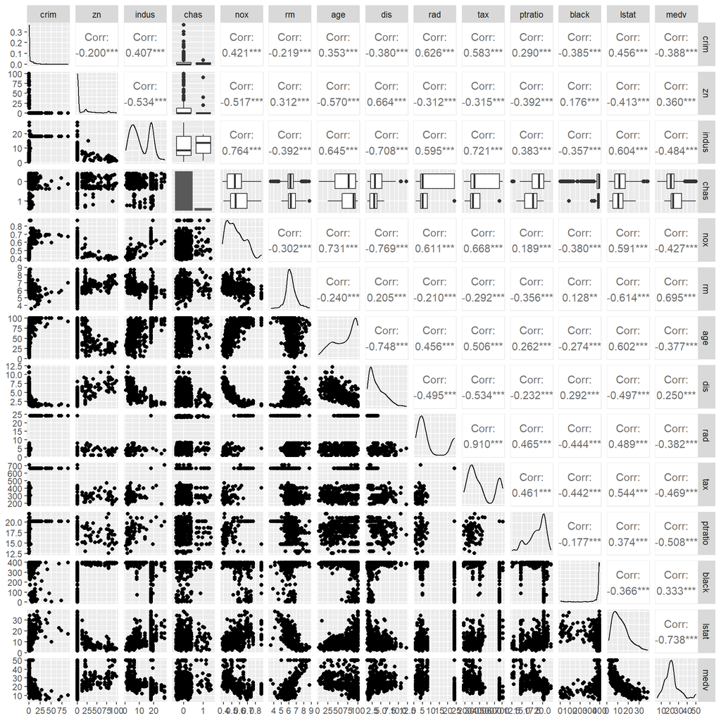

```r
ggpairs(dfBoston, lower = list(continuous = "points", combo = "dot_no_facet"), progress = F)
```

## (b) Fit a multiple regression model to predict the response using all of the predictors.

Describe your results. For which predictors can we reject the null hypothesis H0 : βj = 0?

```r
lm.model.all = lm(crim~.,data=dfBoston)
summary(lm.model.all)
```

```
#>
#> Call:
#> lm(formula = crim ~ ., data = dfBoston)
#>
#> Residuals:
#>    Min     1Q Median     3Q    Max
#> -9.924 -2.120 -0.353  1.019 75.051
#>
#> Coefficients:
#>               Estimate Std. Error t value Pr(>|t|)
#> (Intercept)  17.033228   7.234903   2.354 0.018949 *
#> zn            0.044855   0.018734   2.394 0.017025 *
#> indus        -0.063855   0.083407  -0.766 0.444294
#> chas1        -0.749134   1.180147  -0.635 0.525867
#> nox         -10.313535   5.275536  -1.955 0.051152 .
#> rm            0.430131   0.612830   0.702 0.483089
#> age           0.001452   0.017925   0.081 0.935488
#> dis          -0.987176   0.281817  -3.503 0.000502 ***
#> rad           0.588209   0.088049   6.680 6.46e-11 ***
#> tax          -0.003780   0.005156  -0.733 0.463793
#> ptratio      -0.271081   0.186450  -1.454 0.146611
#> black        -0.007538   0.003673  -2.052 0.040702 *
#> lstat         0.126211   0.075725   1.667 0.096208 .
#> medv         -0.198887   0.060516  -3.287 0.001087 **
#> ---
#> Signif. codes:  0 '***' 0.001 '**' 0.01 '*' 0.05 '.' 0.1 ' ' 1
#>
#> Residual standard error: 6.439 on 492 degrees of freedom
#> Multiple R-squared:  0.454,  Adjusted R-squared:  0.4396
#> F-statistic: 31.47 on 13 and 492 DF,  p-value: < 2.2e-16
```

**Answer q15b:** When all the predictors available in the Boston data set are used only zn, dis, rad, black, and medv are significant in an additive model. Thus, we can reject the null hypothesis H0 : βj = 0 for: * zn * dis * rad * black * medv

when we use an alpha of 0.05.

## (c) How do your results from (a) compare to your results from (b)?

Create a plot displaying the univariate regression coefficients from (a) on the x-axis, and the multiple regression coefficients from (b) on the y-axis. That is, each predictor is displayed as a single point in the plot. Its coefficient in a simple linear regression model is shown on the x-axis, and its coefficient estimate in the multiple linear regression model is shown on the y-axis.

```r
# create the vectors with the coefficients
slr_betas = out_beta[2:14]
print(slr_betas)
```

```
#>  [1] -0.07393498  0.50977633 -1.89277655 31.24853120 -2.68405122  0.10778623
#>  [7] -1.55090168  0.61791093  0.02974225  1.15198279 -0.03627964  0.54880478
#> [13] -0.36315992
```

```r
mlr_betas = as.numeric(coef(lm.model.all)[c(2,3,4,5,6,7,8,9,10,11,12,13,14)])
print(mlr_betas)
```

```
#>  [1]   0.044855215  -0.063854824  -0.749133611 -10.313534912   0.430130506
#>  [6]   0.001451643  -0.987175726   0.588208591  -0.003780016  -0.271080558
#> [11]  -0.007537505   0.126211376  -0.198886821
```

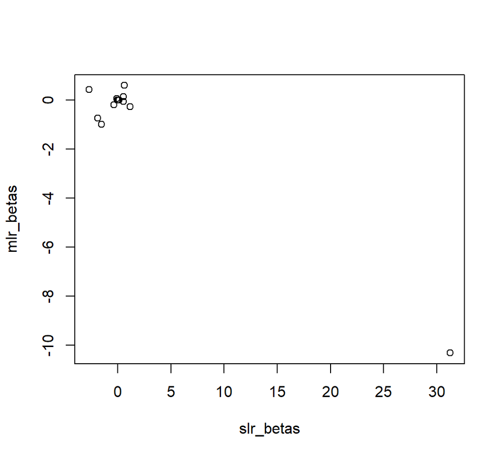

```r
plot(mlr_betas~slr_betas)
```

## (d) Is there evidence of non-linear association…

between any of the predictors and the response? To answer this question, for each predictor X, fit a model of the form
$$Y = β0 + β1X + β2X2 + β3X3 + ..$$

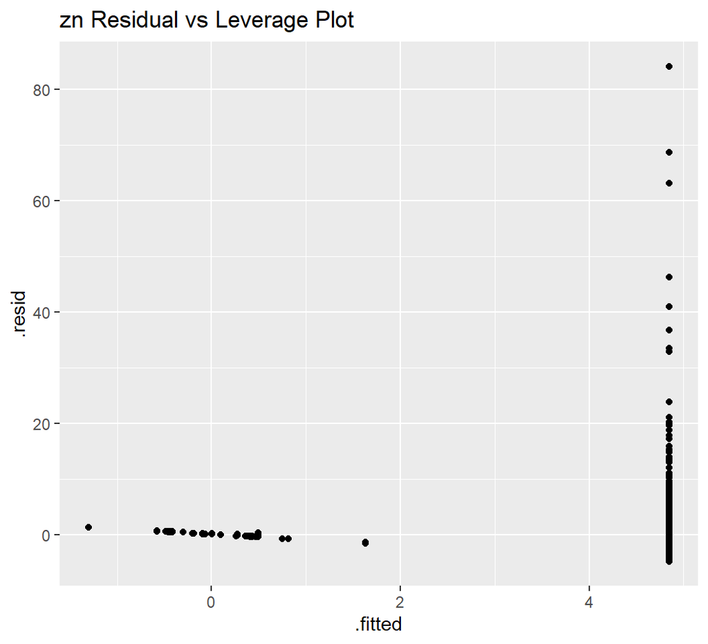

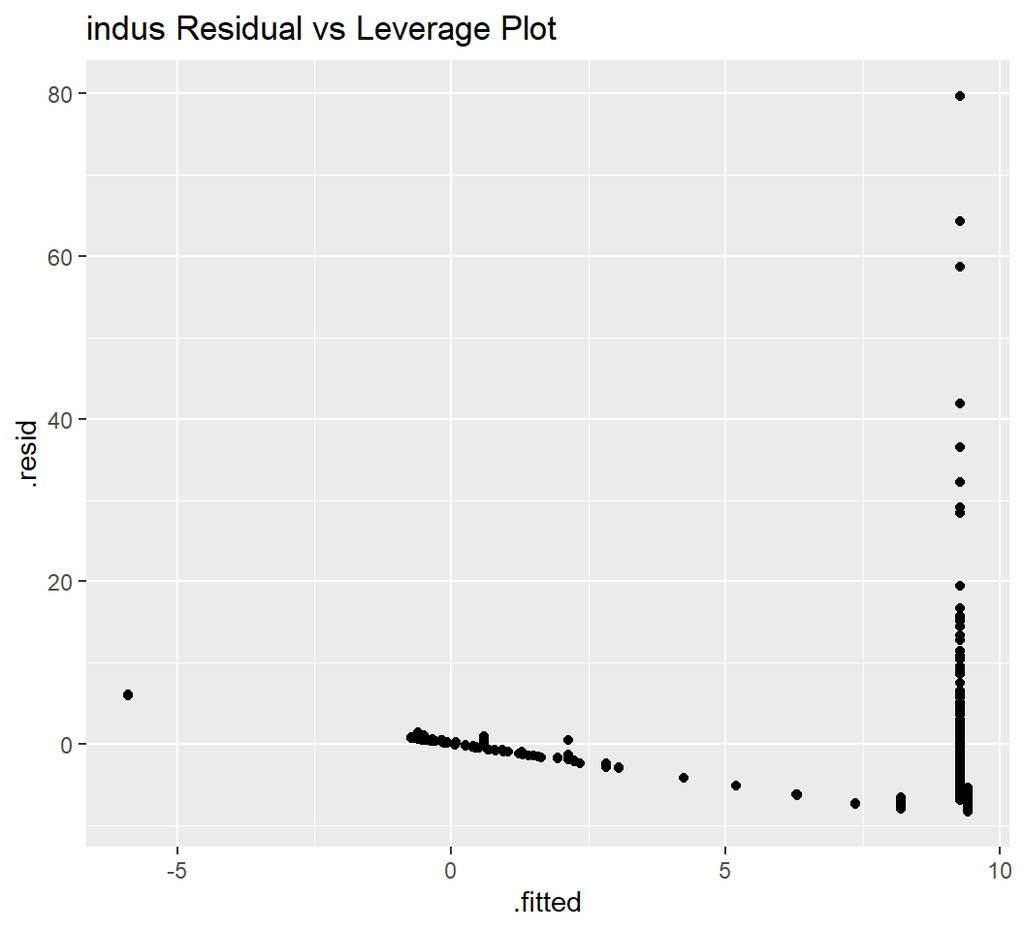

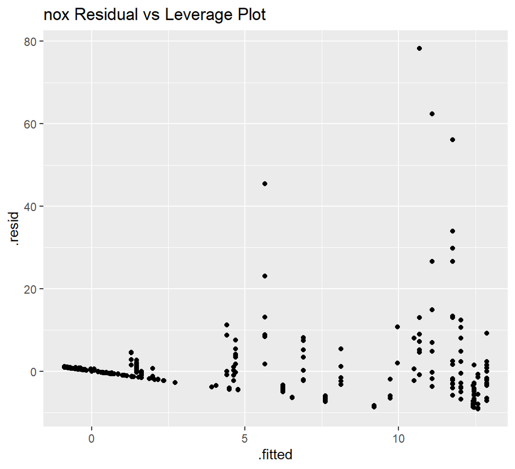

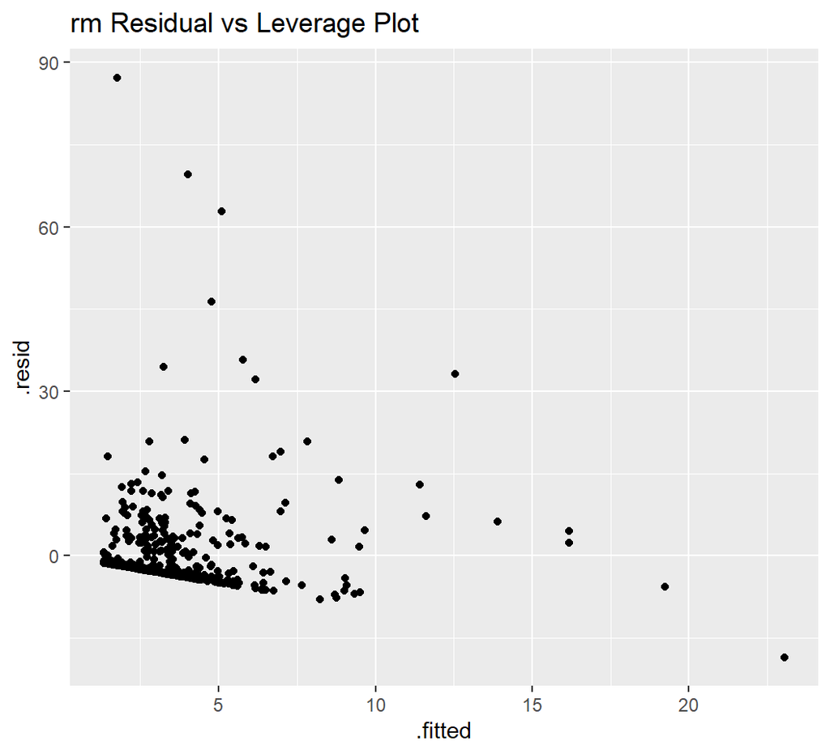

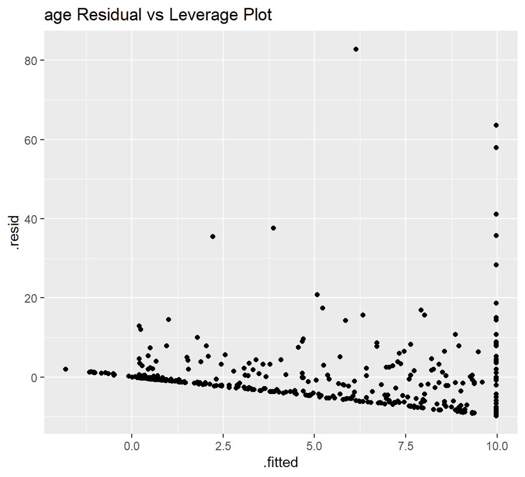

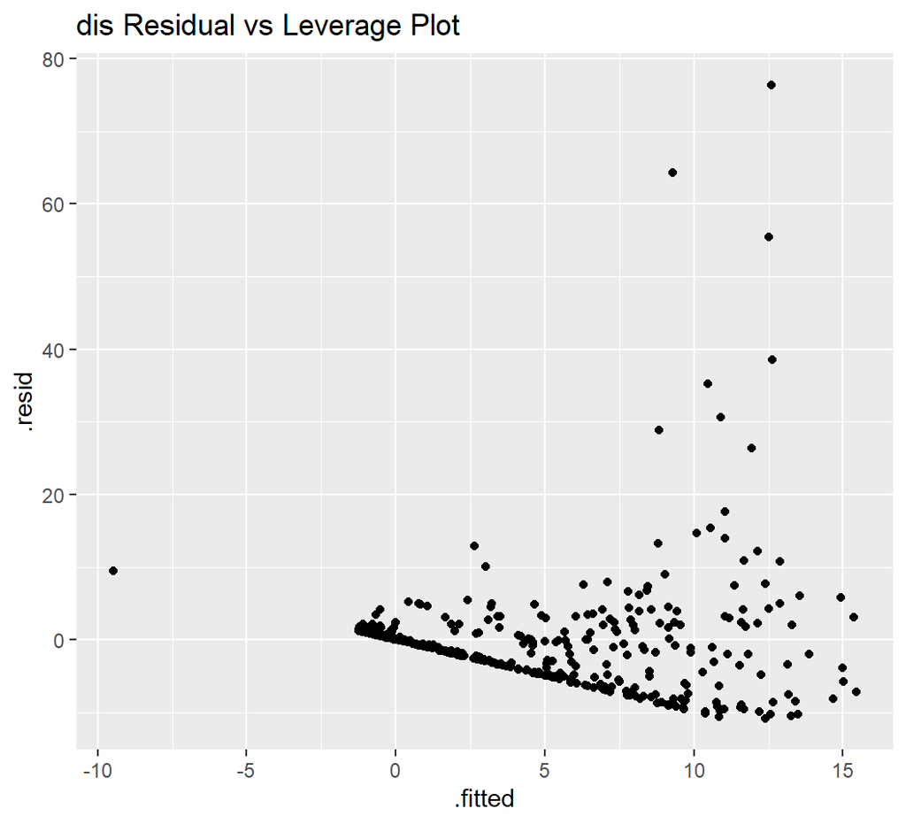

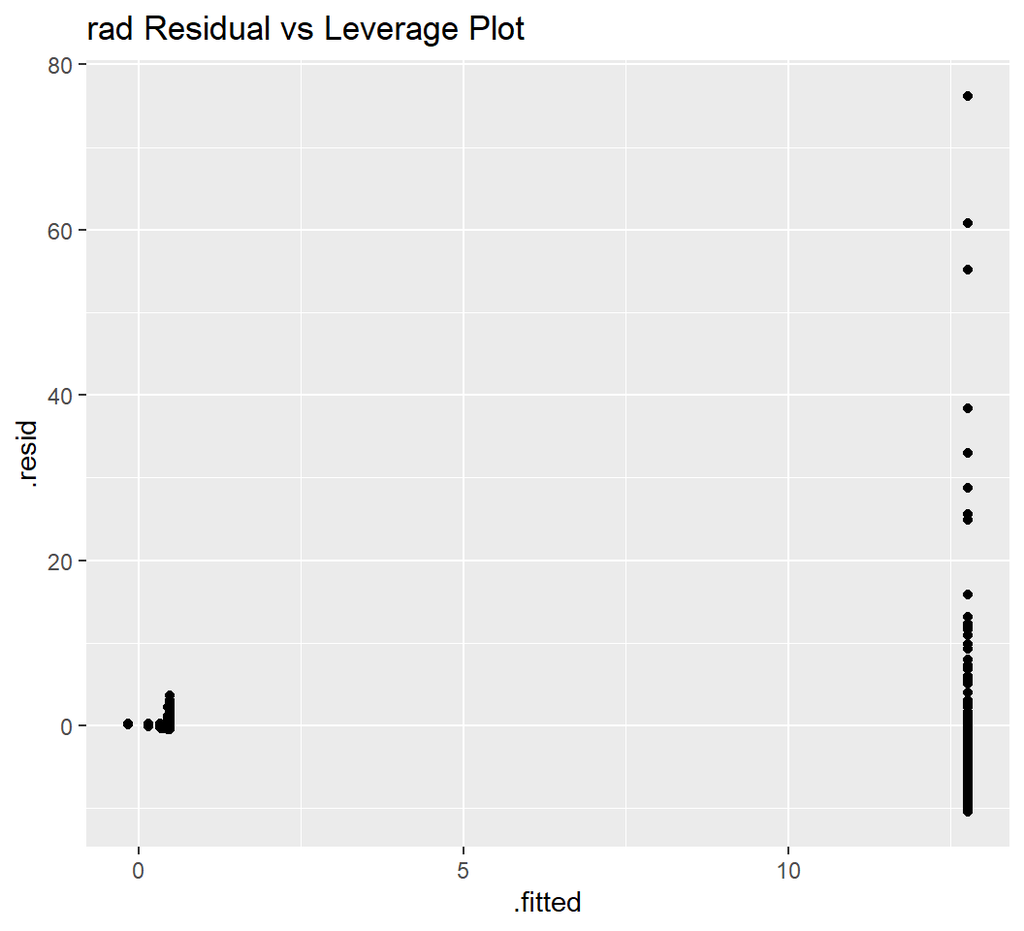

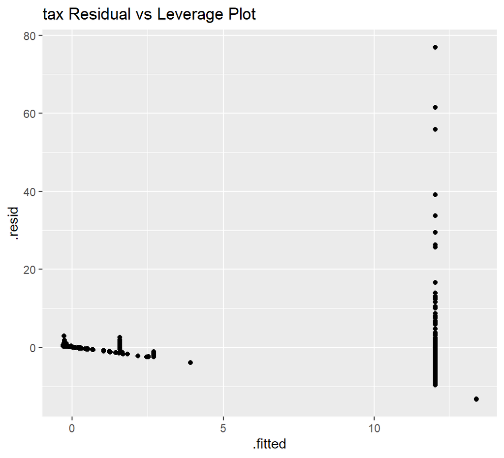

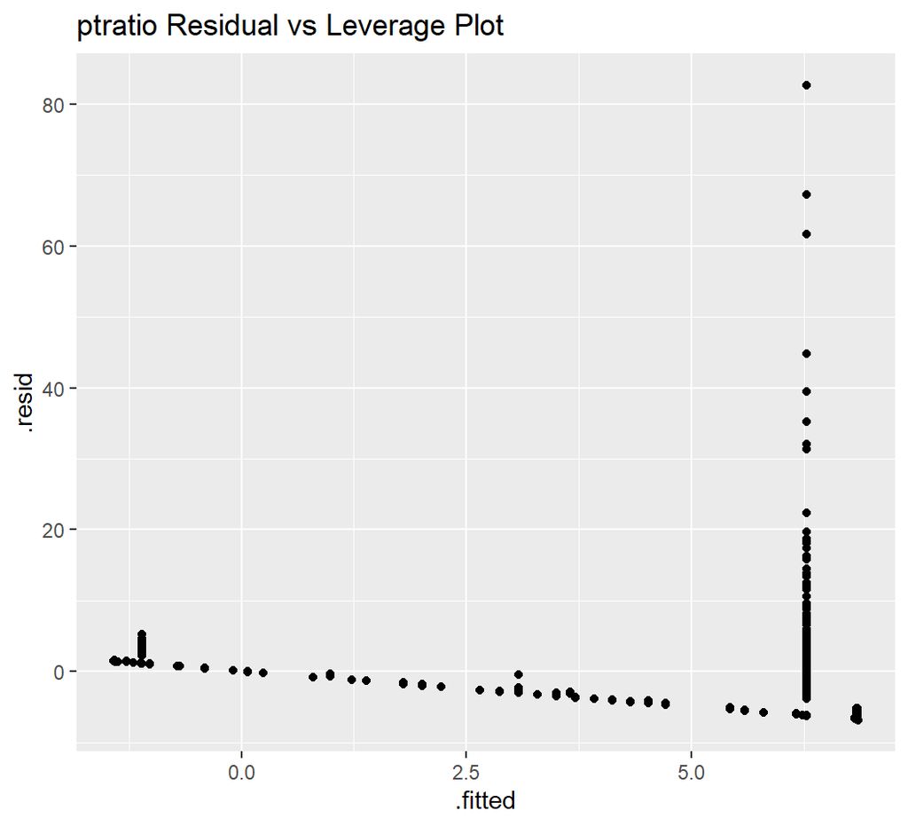

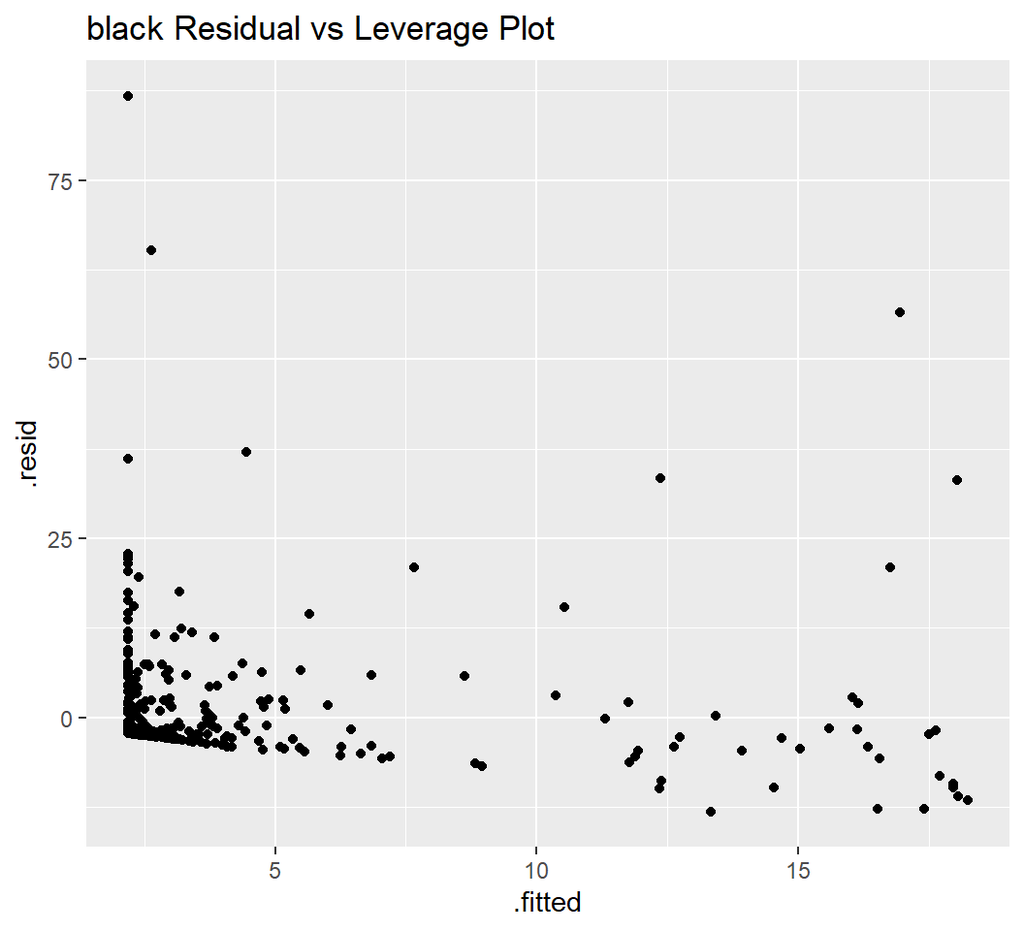

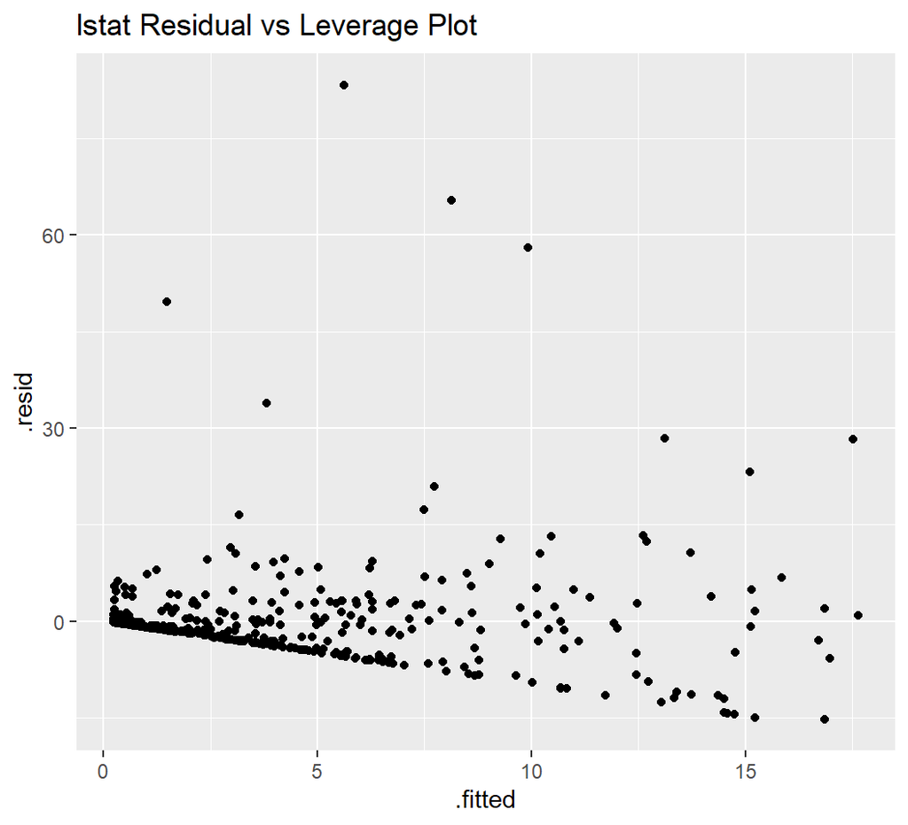

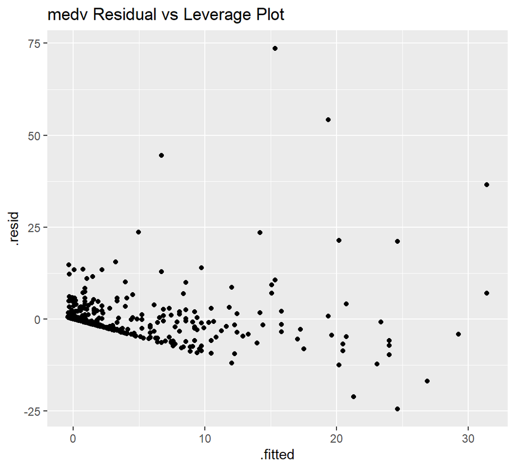

```r
# create vectors of the of outcomes
out_start = 2
out_end = 14
out_nvar = out_end - out_start+1
out_variable = rep(NA, out_nvar)
out_beta = rep(NA, out_nvar)
out_se = rep(NA, out_nvar)
out_pvalue = rep(NA, out_nvar)



for (i in out_start:out_end){

  if (i != 4){
    predictor = colnames(dfBoston)[i]

    model = lm(crim ~ get(predictor) + I(get(predictor)^2) + I(get(predictor)^3) , data=dfBoston)

    df <- fortify(model)
    print(ggplot(df, aes(x = .fitted, y = .resid)) + geom_point() + ggtitle(paste(predictor, "Residual vs Leverage Plot")))

    Vcov = vcov(model, useScale = FALSE)
    beta = coef(model)
    se = sqrt(diag(Vcov))
    zval = beta / se
    pval <- 2 * pnorm(abs(zval), lower.tail = FALSE)


    #print(pval)

    #print(paste("Vcov", i, ": ", Vcov))
    #print(paste("beta: ", beta))
    #print(paste("se: ", se))
    #print(paste("zval: ", zval))
    #print(paste("pval: ", pval))

    out_beta[i] = as.numeric(beta[2])
    out_se[i] = as.numeric(se[2])
    out_pvalue[i] = as.numeric(pval[2])
    out_variable[i] = predictor
    #number = number + 1
  }

}
```

```r
outcome = data.frame(out_variable, out_beta, out_se, out_pvalue)

outcome
```

```
#>    out_variable      out_beta       out_se   out_pvalue
#> 1          <NA>            NA           NA           NA
#> 2            zn -3.321884e-01   0.10980814 2.484925e-03
#> 3         indus -1.965213e+00   0.48199006 4.556378e-05
#> 4          <NA>            NA           NA           NA
#> 5           nox -1.279371e+03 170.39747326 5.996484e-14
#> 6            rm -3.915014e+01  31.31149150 2.111739e-01
#> 7           age  2.736531e-01   0.18637964 1.420345e-01
#> 8           dis -1.555435e+01   1.73596745 3.245340e-19
#> 9           rad  5.127360e-01   1.04359675 6.232028e-01
#> 10          tax -1.533096e-01   0.09567806 1.090785e-01
#> 11      ptratio -8.236054e+01  27.64394247 2.888757e-03
#> 12        black -8.355805e-02   0.05632751 1.379596e-01
#> 13        lstat -4.490656e-01   0.46489111 3.340649e-01
#> 14         medv -5.094831e+00   0.43383205 7.600662e-32
```

**Answer q15d**:  
I did not include the factor chas in my investigation of single predictor cubic models because a cubic model on a single binary factor will not be significant.  
From the scatterplots I did not see evidence of any cubic models for the individual predictors. **medv** is a possibility, but the variance increases dramatically as the fitted value increases. However, the p-values are significant for: * zn * indus * nox * dis * ptratio * and medvD